# MAINS LAB

## 1. Machine learning engineer - test task, 2024

## 2. Task description:

Dataset contains information about medical aid requests by 50000 people insured under VMI in year 2022. You are required to predict number of visits to medical clinic in 2023 on the basis of insured person's features and medical history for year 2022.

Two samples are available:

- train - training and validation sample, 50000 insurees with known target value.
- holdout - test sample, 10000 insurees without target.

Model quality is determined by MSE metric.

**Contents**

1. Machine learning engineer - test task, 2024
2. Task description:
3. Available data:
4. План
5. Load dataset
6. Exploratory Data Analysis  
   6.1. Preface  
   6.2. insured_pin  
   6.3. insured_network  
   6.4. nationality  
   6.5. gender  
   6.6. Date of birth  
   6.7. relation  
   6.8. diagnoses  
   6.9. has_chronic_disease  
   6.10. exposition_22  
   6.11. number_of_visits_22  
   6.12. number_of_services_22  
   6.13. exposition_23  
   6.14. number_of_visits_23  
   6.15. Conclusion
7. Preprocessing  
   7.1. Missing values  
   7.1.1. diagnoses  
   7.1.2. age  
   7.2. Anomalies  
   7.3. Test split  
   7.4. Feature construction  
   7.5. Conclusion
8. Feature Engineering  
   8.1. Preface  
   8.2. Feature Selection  
   8.3. Overview  
   8.4. Int - StandardScaler  
   8.5. Categoricals - OHE  
   8.6. Diagnoses - CountVectorizer  
   8.7. DataFrame - ColumnTransformer  
   8.8. Conclusion
9. Machine Learning  
   9.1. Defines  
   9.2. Search CV  
   9.3. LGBM  
   9.4. XGB  
   9.5. Best model  
   9.6. Test  
   9.7. Feature importances  
   9.8. Conclusion
10. Holdout

## 3. Available data:

**Column description:**

- Insured_PIN - Unique id of the insured person
- Insured_Network - Medical clinic chain id available to insured person. Network - 1 - clinics providing highest level of care, Network - 8 - clinics providing basic services.
- Nationality - gender of the insured person
- Gender - Gender of the insured person
- Relation - Relation to insurance policy holder. self - worker in organization, which bought the policy, child - child of the insured etc.
- DoB - Insured person's date of birth
- Diagnoses - All the diagnoses of the insured as of 2022.
- HasChronicDisease - Chronic disease flag
- Exposition_22 - Number of days in 2022, when insurance policy was in effect. Value of 365 means, that policy was available throughout the whole year (2022).
- number_of_visits_22 - Number of days in 2022, when insured visited clinic for medical assistance
- number_of_services_22 - Number of procedures insuree underwent in 2022(checkups, tests, pharmaceuticals etc.)
- Exposition_23 - Number of days in 2023, when insurance policy was in effect. Value of 365 means, that policy was available throughout the whole year (2023).
- **Target -** number_of_visits_23 - Number of days in 2022, when insured visited clinic for medical assistance. **This value needs to be predicted.**

## 4. План

1. Загрузка
2. Исследовательский анализ
3. Предобработка
4. Обработка признаков
5. Машинное Обучение
6. Финальный замер качества

```python
import pandas as pd
import matplotlib.pyplot as plt

from sklearn.preprocessing import OneHotEncoder, StandardScaler
from sklearn.model_selection import train_test_split, cross_val_score, RandomizedSearchCV
from sklearn.feature_extraction.text import CountVectorizer, TfidfVectorizer
from sklearn.compose import ColumnTransformer
from sklearn.metrics import mean_squared_error

from timeit import default_timer

from sklearn.linear_model import LinearRegression
#from sklearn.ensemble import RandomForestRegressor - too slow
from lightgbm import LGBMRegressor, plot_importance
from xgboost import XGBRegressor
from catboost import CatBoostRegressor
```

```python
pd.set_option('display.max_rows', 30)

RANDOM = 20240804
```

## 5. Load dataset

```python
train = pd.read_excel('ML_train.xlsx', index_col='Insured_PIN')
holdout = pd.read_excel('ML_holdout.xlsx', index_col='Insured_PIN');
```

```python
train.columns
```

```
Index(['Insured_Network', 'Nationality', 'Gender', 'Relation', 'DoB',
       'Diagnoses', 'HasChronicDisease', 'Exposition_22',
       'number_of_visits_22', 'number_of_services_22', 'Exposition_23',
       'number_of_visits_23'],
      dtype='object')
```

```python
holdout.columns
```

```
Index(['Insured_Network', 'Nationality', 'Gender', 'Relation', 'DoB',
       'Diagnoses', 'HasChronicDisease', 'Exposition_22',
       'number_of_visits_22', 'number_of_services_22', 'Exposition_23'],
      dtype='object')
```

```python
train.index.name = train.index.name.lower()
```

```python
train.index.name = train.index.name.lower()
train.index.name = train.index.name.lower()
train.columns = train.columns.str.lower()
holdout.columns = holdout.columns.str.lower()
train.rename(columns = {'haschronicdisease' : 'has_chronic_disease'}, inplace=True)
holdout.rename(columns = {'haschronicdisease' : 'has_chronic_disease'}, inplace=True)
```

```python
train
```

| insured_pin | insured_network | nationality | gender | relation | dob | diagnoses | has_chronic_disease | exposition_22 | number_of_visits_22 | number_of_services_22 | exposition_23 | number_of_visits_23 |
| --- | --- | --- | --- | --- | --- | --- | --- | --- | --- | --- | --- | --- |
| 1006786 | Network-4 | Group 2 | Male | Self | 1974-04-28 | NaN | 0 | 365 | 0 | 0 | 365 | 0 |
| 1008861 | Network-2 | Saudi | Female | Child | 2017-07-27 | J20.9;J02 | 0 | 365 | 1 | 2 | 365 | 4 |
| 1019055 | Network-5 | Group 2 | Male | Self | 1979-02-20 | J03.9 | 0 | 365 | 1 | 4 | 365 | 5 |
| 1019438 | Network-1 | Saudi | Male | Self | 1985-05-09 | E56.9;J02;J00 | 1 | 365 | 3 | 18 | 365 | 11 |
| 1027311 | Network-3 | Group 3 | Male | Self | 1962-01-01 | NaN | 0 | 365 | 0 | 0 | 365 | 0 |
| ... | ... | ... | ... | ... | ... | ... | ... | ... | ... | ... | ... | ... |
| 987424 | Network-4 | Saudi | Male | Child | 2000-09-15 | NaN | 0 | 365 | 0 | 0 | 365 | 0 |
| 991750 | Network-3 | Group 2 | Female | Spouse | 1982-05-27 | J30.4;R51;J03;UNKRC;N36.3;R69;N81;R10;N39.0;G5... | 1 | 365 | 22 | 62 | 365 | 16 |
| 9932157 | Network-5 | Group 1 | Male | Child | 2001-12-27 | M50.1;J45.0;K29;R07.4;M25.5;J03;J06.9 | 0 | 365 | 5 | 19 | 365 | 4 |
| 9950431 | Network-1 | Group 4 | Male | Self | 1966-08-13 | R69;N39.0;I10;J02.9;E78.0;J02;E11;E55.9;E09.21... | 1 | 365 | 14 | 56 | 365 | 10 |
| 9952098 | Network-1 | Group 4 | Female | Child | 2008-01-12 | J06 | 0 | 365 | 1 | 5 | 365 | 0 |

50000 rows × 12 columns

```python
train.info()
```

```
<class 'pandas.core.frame.DataFrame'>
Int64Index: 50000 entries, 1006786 to 9952098
Data columns (total 12 columns):
 #   Column                 Non-Null Count  Dtype
---  ------                 --------------  -----
 0   insured_network        50000 non-null  object
 1   nationality            50000 non-null  object
 2   gender                 50000 non-null  object
 3   relation               50000 non-null  object
 4   dob                    49999 non-null  datetime64[ns]
 5   diagnoses              41226 non-null  object
 6   has_chronic_disease    50000 non-null  int64
 7   exposition_22          50000 non-null  int64
 8   number_of_visits_22    50000 non-null  int64
 9   number_of_services_22  50000 non-null  int64
 10  exposition_23          50000 non-null  int64
 11  number_of_visits_23    50000 non-null  int64
dtypes: datetime64[ns](1), int64(6), object(5)
memory usage: 5.0+ MB
```

```python
holdout.info()
```

```
<class 'pandas.core.frame.DataFrame'>
Int64Index: 10000 entries, 1516424 to 1384402
Data columns (total 11 columns):
 #   Column                 Non-Null Count  Dtype
---  ------                 --------------  -----
 0   insured_network        10000 non-null  object
 1   nationality            10000 non-null  object
 2   gender                 10000 non-null  object
 3   relation               10000 non-null  object
 4   dob                    10000 non-null  datetime64[ns]
 5   diagnoses              8274 non-null   object
 6   has_chronic_disease    10000 non-null  int64
 7   exposition_22          10000 non-null  int64
 8   number_of_visits_22    10000 non-null  int64
 9   number_of_services_22  10000 non-null  int64
 10  exposition_23          10000 non-null  int64
dtypes: datetime64[ns](1), int64(5), object(5)
memory usage: 937.5+ KB
```

```python
train.describe(datetime_is_numeric=True)
```

|  | dob | has_chronic_disease | exposition_22 | number_of_visits_22 | number_of_services_22 | exposition_23 | number_of_visits_23 |
| --- | --- | --- | --- | --- | --- | --- | --- |
| count | 49999 | 50000.000000 | 50000.000000 | 50000.000000 | 50000.000000 | 50000.000000 | 50000.000000 |
| mean | 1990-02-22 19:50:30.036600704 | 0.337940 | 358.898960 | 5.740320 | 22.477420 | 355.588420 | 5.898860 |
| min | 1920-03-21 00:00:00 | 0.000000 | 50.000000 | 0.000000 | 0.000000 | 50.000000 | 0.000000 |
| 25% | 1971-03-23 00:00:00 | 0.000000 | 365.000000 | 1.000000 | 3.000000 | 365.000000 | 1.000000 |
| 50% | 1991-11-13 00:00:00 | 0.000000 | 365.000000 | 4.000000 | 13.000000 | 365.000000 | 4.000000 |
| 75% | 2011-04-17 00:00:00 | 1.000000 | 365.000000 | 8.000000 | 31.000000 | 365.000000 | 8.000000 |
| max | 2022-11-12 00:00:00 | 1.000000 | 365.000000 | 151.000000 | 962.000000 | 365.000000 | 202.000000 |
| std | NaN | 0.473013 | 35.562003 | 6.592556 | 29.714146 | 43.779065 | 6.856904 |

```python
train.diagnoses.isnull().sum()
```

```
8774
```

**Corollary:** Dataset is loaded into two variables. Columns renamed to `snake_case`. `holdout` is not examined in detail to avoid data leaks. As `holdout` target is unavailable, it is useful to split part of train set into test before proceeding with cross validation. Will do so after EDA.

The train sample contains 13 features, `diagnoses` contains significant (20%) number of missing values, some features like `nationality`, `insured_network` and `relation` seem unlikely to impact target value. Additionally `insured_network` poses business interest, as it is likely to increase costs for medical services.

## 6. Exploratory Data Analysis

### 6.1. Preface

In this section data analysis only, DataFrame changes will be performed in the next one.

```python
def target_breakdown(feature: str, df=train, head=20): # quick print for number of visits in 22 and 23 based on a feature name (string)
    return pd. concat(
    [df[feature].value_counts(normalize=True) * 100,
    df[feature].value_counts(),
    df['number_of_visits_22'].groupby(df[feature]).mean(),
    df['number_of_visits_23'].groupby(df[feature]).mean()],
      axis = 1, keys = ['percentage', 'total', 'visits_mean_22', 'visits_mean_23']).head(head) \
        .style.set_caption(feature) \
        .set_table_styles([{
            'selector': 'caption',
            'props': [('font-weight', 'bold')]
            }])
```

```python
def target_corr(feature:str): # correlation number of visits in 22 and 23 based on a feature name (string)
    return pd.DataFrame(train[[feature, 'number_of_visits_22', 'number_of_visits_23']].corr()[feature].drop(feature)).rename(columns={feature:'corr with '+feature})
```

**Corollary:** Functions allow to quickly estimate distribution and correlation with target.

### 6.2. insured_pin

```python
train.index.append(holdout.index).duplicated().sum()
```

```
0
```

**Corollary:** No duplicates, primary key is valid.

### 6.3. insured_network

```python
train['insured_network'].unique()
```

```
array(['Network-4', 'Network-2', 'Network-5', 'Network-1', 'Network-3',
       'Network-6', 'Network-7', 'Network-8'], dtype=object)
```

```python
target_breakdown('insured_network')
```

insured_network

|  | percentage | total | visits_mean_22 | visits_mean_23 |
| --- | --- | --- | --- | --- |
| Network-2 | 93.114000 | 46557 | 5.789226 | 5.937947 |
| Network-1 | 2.930000 | 1465 | 6.772696 | 6.943345 |
| Network-4 | 1.922000 | 961 | 4.071800 | 4.480749 |
| Network-5 | 1.132000 | 566 | 3.379859 | 3.927562 |
| Network-3 | 0.560000 | 280 | 5.017857 | 5.203571 |
| Network-6 | 0.242000 | 121 | 1.834711 | 1.785124 |
| Network-7 | 0.088000 | 44 | 2.477273 | 2.454545 |
| Network-8 | 0.012000 | 6 | 0.500000 | 1.333333 |

```python
train['number_of_visits_23'].groupby(train['insured_network'] == 'Network-2').mean()
```

```
insured_network
False    5.370317
True     5.937947
Name: number_of_visits_23, dtype: float64
```

**Corollary:** Overwhelming class imbalance creates an issue here - even if there's prognostic value in adding this feature to the model it is likely to create issues should future data not conform to the same distribution.

### 6.4. nationality

```python
train['nationality'].unique()
```

```
array(['Group 2', 'Saudi', 'Group 3', 'Group 4', 'Others', 'Group 1'],
      dtype=object)
```

```python
target_breakdown('nationality')
```

nationality

|  | percentage | total | visits_mean_22 | visits_mean_23 |
| --- | --- | --- | --- | --- |
| Saudi | 93.392000 | 46696 | 5.758202 | 5.921321 |
| Group 2 | 2.798000 | 1399 | 4.690493 | 4.857756 |
| Group 3 | 2.224000 | 1112 | 6.449640 | 6.468525 |
| Group 4 | 0.614000 | 307 | 6.410423 | 6.833876 |
| Others | 0.494000 | 247 | 6.902834 | 6.311741 |
| Group 1 | 0.478000 | 239 | 3.029289 | 3.326360 |

```python
train['number_of_visits_23'].groupby(train['nationality'] == 'Saudi').mean()
```

```
nationality
False    5.581416
True     5.921321
Name: number_of_visits_23, dtype: float64
```

```python
train['insured_network'][train['nationality'] == 'Saudi'].value_counts(normalize=True) * 100
```

```
Network-2    96.083176
Network-1     2.317115
Network-4     1.190680
Network-3     0.207727
Network-5     0.197019
Network-8     0.002142
Network-7     0.002142
Name: insured_network, dtype: float64
```

**Corollary:** Most insurees are saudi. It is hard to see how this feature affects target, and similarly to `network_id` there's a large imbalance, but it is hard to justify balancing classes, given low impact and small quantity of records outside of the majority class. There's a little more representation of `Network-2` among `Saudi`, but not complete overlap, reducing possibility that the majority class is a data error.

### 6.5. gender

```python
train['gender'].unique()
```

```
array(['Male', 'Female'], dtype=object)
```

```python
target_breakdown('gender')
```

gender

|  | percentage | total | visits_mean_22 | visits_mean_23 |
| --- | --- | --- | --- | --- |
| Male | 51.168000 | 25584 | 5.438360 | 5.580128 |
| Female | 48.832000 | 24416 | 6.056725 | 6.232839 |

**Corollary:** The number of man and women in the population is close to equal. No class balancing is necessary. There is some difference between genders in regards to target. It is possible that models working with each gender separately will provide better results.

### 6.6. Date of birth

```python
train['dob'].describe(datetime_is_numeric=True)
```

```
count                            49999
mean     1990-02-22 19:50:30.036600704
min                1920-03-21 00:00:00
25%                1971-03-23 00:00:00
50%                1991-11-13 00:00:00
75%                2011-04-17 00:00:00
max                2022-11-12 00:00:00
Name: dob, dtype: object
```

```python
age = (2023 - train['dob'].dt.year).rename('age')
age.describe()
```

```
count    49999.000000
mean        33.365907
std         22.741768
min          1.000000
25%         12.000000
50%         32.000000
75%         52.000000
max        103.000000
Name: age, dtype: float64
```

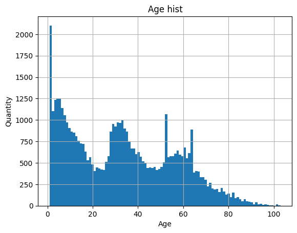

```python
age.hist(bins=100)
plt.title('Age hist')
plt.ylabel('Quantity')
plt.xlabel('Age');
```

```python
train[train['dob'].isnull()]
```

| insured_pin | insured_network | nationality | gender | relation | dob | diagnoses | has_chronic_disease | exposition_22 | number_of_visits_22 | number_of_services_22 | exposition_23 | number_of_visits_23 |
| --- | --- | --- | --- | --- | --- | --- | --- | --- | --- | --- | --- | --- |
| 1451433 | Network-2 | Saudi | Male | Self | NaT | H93.1;A09.9;R10;N39.0;M79;E78.5;N77.1;M23;E11.... | 1 | 365 | 15 | 62 | 365 | 14 |

```python
train[(train['dob'] > '2008') & (train.relation != 'Child')]
```

| insured_pin | insured_network | nationality | gender | relation | dob | diagnoses | has_chronic_disease | exposition_22 | number_of_visits_22 | number_of_services_22 | exposition_23 | number_of_visits_23 |
| --- | --- | --- | --- | --- | --- | --- | --- | --- | --- | --- | --- | --- |
| 2622146 | Network-1 | Saudi | Male | Self | 2011-02-06 | J03;J00 | 1 | 365 | 2 | 3 | 365 | 3 |
| 4231556 | Network-2 | Saudi | Female | Spouse | 2011-01-26 | NaN | 0 | 365 | 0 | 0 | 365 | 1 |
| 86461104 | Network-1 | Saudi | Male | Other | 2008-07-04 | E14.11;E55;E10;K90.9;A09.9;J20;A09;E11 | 1 | 365 | 14 | 90 | 365 | 25 |

```python
train[(train['dob'] < '1932')].relation.value_counts()
```

```
Self      136
Parent      1
Name: relation, dtype: int64
```

```python
age_target = pd.concat([
    age,
    train['number_of_visits_22'],
    train['number_of_visits_23']
    ], axis=1, keys=['age', 'number_of_visits_22', 'number_of_visits_23'])

pd.DataFrame(age_target.corr()['age'].drop('age')).rename(columns={'age':'corr with age'})
```

|  | corr with age |
| --- | --- |
| number_of_visits_22 | 0.069100 |
| number_of_visits_23 | 0.090506 |

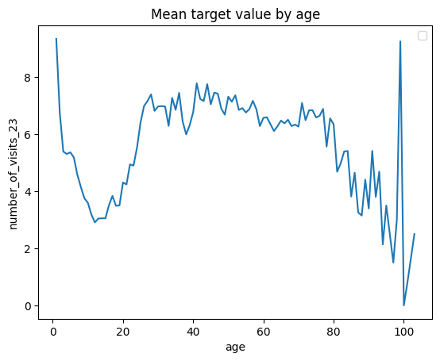

```python
age_target.groupby('age').mean().plot( y='number_of_visits_23')
plt.title('Mean target value by age')
plt.legend('')
plt.ylabel('number_of_visits_23');
```

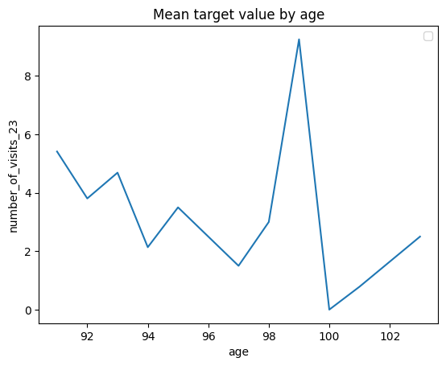

```python
age_target[age_target['age'] > 90].groupby('age').mean().plot( y='number_of_visits_23')
plt.title('Mean target value by age')
plt.legend('')
plt.ylabel('number_of_visits_23');
```

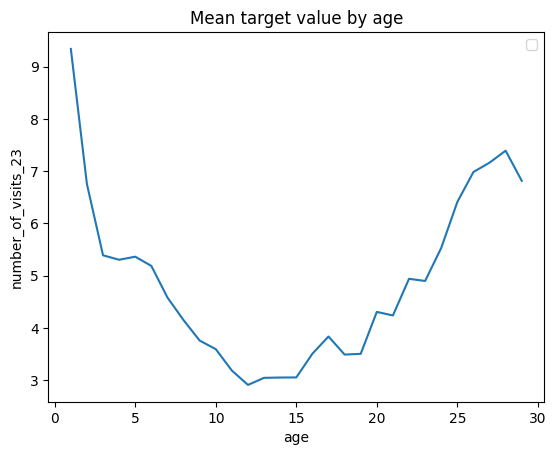

```python
age_target[age_target['age'] < 30].groupby('age').mean().plot( y='number_of_visits_23')
plt.title('Mean target value by age')
plt.legend('')
plt.ylabel('number_of_visits_23');
```

```python
pd.concat(
    [pd.concat([
        pd.qcut(age, 20),
        train['number_of_visits_23']
        ],axis=1, keys=['age_bin', 'number_of_visits_23']).groupby('age_bin').mean(),
     pd.qcut(age, 20).value_counts()
    ], axis=1).rename(columns={'age':'quantity'}).style.set_caption('QCUT 20')
```

QCUT 20

|  | number_of_visits_23 | quantity |
| --- | --- | --- |
| (0.999, 3.0] | 7.059576 | 3206 |
| (3.0, 5.0] | 5.333872 | 2477 |
| (5.0, 7.0] | 4.897993 | 2392 |
| (7.0, 9.0] | 3.961045 | 2028 |
| (9.0, 12.0] | 3.235831 | 2629 |
| (12.0, 15.0] | 3.048780 | 2296 |
| (15.0, 20.0] | 3.704499 | 2934 |
| (20.0, 25.0] | 5.204342 | 2119 |
| (25.0, 29.0] | 7.085370 | 2905 |
| (29.0, 32.0] | 6.973427 | 2860 |
| (32.0, 34.0] | 6.753952 | 1898 |
| (34.0, 37.0] | 6.928509 | 2280 |
| (37.0, 42.0] | 6.778300 | 2977 |
| (42.0, 47.0] | 7.360526 | 2280 |
| (47.0, 52.0] | 7.092294 | 2297 |
| (52.0, 57.0] | 6.914849 | 2889 |
| (57.0, 61.0] | 6.584966 | 2501 |
| (61.0, 64.0] | 6.245017 | 2057 |
| (64.0, 72.0] | 6.452652 | 2640 |
| (72.0, 103.0] | 5.659383 | 2334 |

```python
pd.concat(
    [pd.concat([
        pd.cut(age, 20),
        train['number_of_visits_23']
        ],axis=1, keys=['age_bin', 'number_of_visits_23']).groupby('age_bin').mean(),
     pd.cut(age, 20).value_counts()
    ], axis=1).rename(columns={'age':'quantity'}).style.set_caption('CUT 20')
```

CUT 20

|  | number_of_visits_23 | quantity |
| --- | --- | --- |
| (0.898, 6.1] | 6.104815 | 6936 |
| (6.1, 11.2] | 3.900223 | 4941 |
| (11.2, 16.3] | 3.103252 | 3874 |
| (16.3, 21.4] | 3.841622 | 2614 |
| (21.4, 26.5] | 5.787607 | 2227 |
| (26.5, 31.6] | 7.049196 | 4289 |
| (31.6, 36.7] | 6.934792 | 4478 |
| (36.7, 41.8] | 6.632438 | 3126 |
| (41.8, 46.9] | 7.321398 | 2346 |
| (46.9, 52.0] | 7.145613 | 2747 |
| (52.0, 57.1] | 6.914849 | 2889 |
| (57.1, 62.2] | 6.542212 | 3056 |
| (62.2, 67.3] | 6.314987 | 2689 |
| (67.3, 72.4] | 6.452856 | 1453 |
| (72.4, 77.5] | 6.762500 | 960 |
| (77.5, 82.6] | 5.655072 | 690 |
| (82.6, 87.7] | 4.583120 | 391 |
| (87.7, 92.8] | 3.827411 | 197 |
| (92.8, 97.9] | 2.875000 | 72 |
| (97.9, 103.0] | 2.583333 | 24 |

**Corollary:** There is a single missing value, it's likely safe to replace it with mean of a sample with similar features. There are some anomalies in data, when it comes to people at the extremes of the age range, but they are hard to interpret without more information so are better left as is.

When it comes to age, 75% of insurees are below 52 years. There are dips in the age distribution around 22 and 45 years of age, likely due to parents and children being mostly below and above that range, adding to the overall number. There's not a correlation between age and target, but it is possible that combination of age, diagnosis and other factors are useful for prediction. It is notable that the very young children have the most visits, as do very elderly, though in latter case it's hard to be sure given how few records are available. It might be useful to create features based on age ranges, especially for toddlers and young children as those ranges have pronounced target divergence from the average.

### 6.7. relation

```python
train['relation'].unique()
```

```
array(['Self', 'Child', 'Spouse', 'Parent', 'Other'], dtype=object)
```

```python
pd.concat([age, train.relation], axis=1).pivot_table(index='relation', margins=True)
```

| relation | age |
| --- | --- |
| Child | 10.307857 |
| Other | 42.384615 |
| Parent | 68.637681 |
| Self | 52.306393 |
| Spouse | 37.493052 |
| All | 33.365907 |

```python
target_breakdown('relation')
```

relation

|  | percentage | total | visits_mean_22 | visits_mean_23 |
| --- | --- | --- | --- | --- |
| Self | 43.678000 | 21839 | 6.017034 | 6.366500 |
| Child | 39.148000 | 19574 | 4.570808 | 4.531011 |
| Spouse | 16.984000 | 8492 | 7.663095 | 7.806406 |
| Parent | 0.138000 | 69 | 11.028986 | 9.869565 |
| Other | 0.052000 | 26 | 11.730769 | 9.307692 |

**Corollary:** It might be prudent to consider impact this category has on profitability, however without more information about insurance conditions it is difficult to do so. Parents and children diverge in age from the average. It is notable that large number of children sways average below most categories. Because age is known for nearly all insured persons, I suspect this category will bear little relevance in terms of determining number of visits otherwise. It is likely that it can be dropped safely.

### 6.8. diagnoses

```python
train.diagnoses
```

```
insured_pin
1006786                                                  NaN
1008861                                            J20.9;J02
1019055                                                J03.9
1019438                                        E56.9;J02;J00
1027311                                                  NaN
                                 ...
987424                                                   NaN
991750     J30.4;R51;J03;UNKRC;N36.3;R69;N81;R10;N39.0;G5...
9932157                M50.1;J45.0;K29;R07.4;M25.5;J03;J06.9
9950431    R69;N39.0;I10;J02.9;E78.0;J02;E11;E55.9;E09.21...
9952098                                                  J06
Name: diagnoses, Length: 50000, dtype: object
```

```python
train.diagnoses.unique().size
```

```
35467
```

```python
diagnoses_as_lists = train.diagnoses.fillna('no_diagnoses').str.lower().str.split(';')
diagnoses_as_lists
```

```
insured_pin
1006786                                       [no_diagnoses]
1008861                                         [j20.9, j02]
1019055                                              [j03.9]
1019438                                    [e56.9, j02, j00]
1027311                                       [no_diagnoses]
                                 ...
987424                                        [no_diagnoses]
991750     [j30.4, r51, j03, unkrc, n36.3, r69, n81, r10,...
9932157        [m50.1, j45.0, k29, r07.4, m25.5, j03, j06.9]
9950431    [r69, n39.0, i10, j02.9, e78.0, j02, e11, e55....
9952098                                                [j06]
Name: diagnoses, Length: 50000, dtype: object
```

```python
diagnoses_as_lists.explode().unique().size
```

```
6225
```

```python
any(diagnoses_as_lists.map(len) != diagnoses_as_lists.map(lambda x: len(set(x))))
```

```
False
```

```python
train[['number_of_services_22', 'number_of_visits_22', 'number_of_visits_23']].groupby(train.diagnoses.isna()).mean()
```

| diagnoses | number_of_services_22 | number_of_visits_22 | number_of_visits_23 |
| --- | --- | --- | --- |
| False | 27.261219 | 6.962014 | 6.849391 |
| True | 0.000000 | 0.000000 | 1.432642 |

```python
diagnoses_counts = pd.concat([
    diagnoses_as_lists[~diagnoses_as_lists.map(lambda x: x == ['no_diagnoses'])].map(len),
    pd.Series(0, train.index[train.diagnoses.isna()])
]).rename('diagnoses_counts')
target_breakdown('diagnoses_counts', pd.concat([train, diagnoses_counts], axis=1))
```

diagnoses_counts

|  | percentage | total | visits_mean_22 | visits_mean_23 |
| --- | --- | --- | --- | --- |
| 0 | 17.548000 | 8774 | 0.000000 | 1.432642 |
| 1 | 10.518000 | 5259 | 1.180262 | 2.647081 |
| 2 | 9.908000 | 4954 | 2.202463 | 3.361930 |
| 3 | 8.648000 | 4324 | 3.251156 | 4.222017 |
| 4 | 7.914000 | 3957 | 4.352793 | 5.067728 |
| 5 | 6.778000 | 3389 | 5.372676 | 5.694895 |
| 6 | 5.988000 | 2994 | 6.306279 | 6.464930 |
| 7 | 5.024000 | 2512 | 7.233280 | 6.933917 |
| 8 | 4.342000 | 2171 | 8.216029 | 7.846154 |
| 9 | 3.718000 | 1859 | 9.235073 | 8.601937 |
| 10 | 3.046000 | 1523 | 10.204859 | 8.954038 |
| 11 | 2.640000 | 1320 | 11.259848 | 9.984848 |
| 12 | 2.082000 | 1041 | 12.286263 | 10.852065 |
| 13 | 1.934000 | 967 | 13.135471 | 11.280248 |
| 14 | 1.558000 | 779 | 13.776637 | 11.589217 |
| 15 | 1.268000 | 634 | 14.766562 | 12.345426 |
| 16 | 1.108000 | 554 | 15.817690 | 13.075812 |
| 17 | 0.804000 | 402 | 16.104478 | 13.308458 |
| 18 | 0.816000 | 408 | 17.786765 | 15.049020 |
| 19 | 0.698000 | 349 | 17.429799 | 14.369628 |

```python
train[['number_of_services_22', 'number_of_visits_22', 'number_of_visits_23']].corrwith(diagnoses_counts)
```

```
number_of_services_22    0.828579
number_of_visits_22      0.861860
number_of_visits_23      0.608565
dtype: float64
```

```python
train[['number_of_services_22', 'number_of_visits_22', 'number_of_visits_23']].groupby(train.diagnoses.isna()).mean()
```

| diagnoses | number_of_services_22 | number_of_visits_22 | number_of_visits_23 |
| --- | --- | --- | --- |
| False | 27.261219 | 6.962014 | 6.849391 |
| True | 0.000000 | 0.000000 | 1.432642 |

**Corollary:** Given the complete absence of visits and services in 22, missing values appear to be people whe weren't sick in 22. This allows to fill them with a dummy noting that fact. It also suggest the possibility of using this feature to construct another - number of diagnoses patient had in 22. It shows decent correlation with `number_of_visits_23`, so decent that ti raises collinearity concerns with `number_of_visits_22` and `number_of_services_22`.

Alternatively, if used as text, this feature presents a challenge for machine learning due to large number of unique diagnoses. The most straightforward way to use it is to make each diagnose a unique boolean feature. It is possible that this can be improved by using Inverse Document Frequency to detect rare diagnoses. This, if successful, would allow detection of connection between diseases and frequency of visits. The downside of this approach is that it creates a large quantity of features.

It might be possible to use dimensionality reduction to alleviate issue somewhat, tho at the cost of some data loss and ability to interpret results. On the other hand, if computational power is non-issue, it is to use correlations to detect combinations of diagnoses possibly resulting in better accuracy.

### 6.9. has_chronic_disease

```python
train['has_chronic_disease'].unique()
```

```
array([0, 1], dtype=int64)
```

```python
target_breakdown('has_chronic_disease')
```

has_chronic_disease

|  | percentage | total | visits_mean_22 | visits_mean_23 |
| --- | --- | --- | --- | --- |
| 0 | 66.206000 | 33103 | 3.254176 | 4.016131 |
| 1 | 33.794000 | 16897 | 10.610937 | 9.587323 |

**Corollary:** A very clear cut and useful feature, likely to play a major role in predicting target. It is appropriate to change it to bool as it's a flag. On the business end presents somewhat of an issue as many insurance companies hesitate to ensure people with chronic conditions, furthermore legislation might affect the role this feature plays in decision making.

### 6.10. exposition_22

```python
train['exposition_22'].describe()
```

```
count    50000.000000
mean       358.898960
std         35.562003
min         50.000000
25%        365.000000
50%        365.000000
75%        365.000000
max        365.000000
Name: exposition_22, dtype: float64
```

```python
train['exposition_22'].value_counts().head(5)
```

```
365    48153
61        26
122       25
364       23
196       21
Name: exposition_22, dtype: int64
```

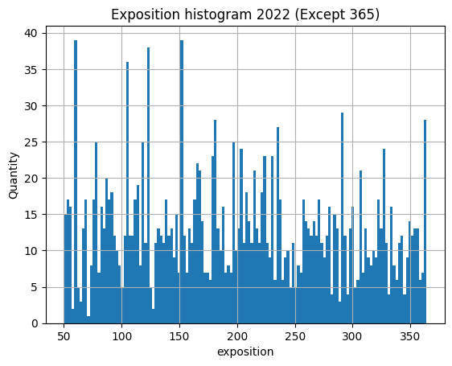

```python
train['exposition_22'][train['exposition_22'] < 365].hist(bins=140)
plt.title('Exposition histogram 2022 (Except 365)')
plt.xlabel('exposition')
plt.ylabel('Quantity');
```

```python
target_corr('exposition_22')
```

|  | corr with exposition_22 |
| --- | --- |
| number_of_visits_22 | 0.060615 |
| number_of_visits_23 | -0.045779 |

```python
pd.DataFrame(train[['exposition_22', 'number_of_visits_22', 'number_of_visits_23']][train['exposition_22'] < 365].corr()['exposition_22'].drop('exposition_22')) \
    .rename(columns={'exposition_22':'corr with exposition_22 for values below 365'})
```

|  | corr with exposition_22 for values below 365 |
| --- | --- |
| number_of_visits_22 | 0.358111 |
| number_of_visits_23 | -0.025974 |

```python
train['number_of_visits_22'].groupby(train['exposition_22'] == 365).mean()
```

```
exposition_22
False    4.365457
True     5.793055
Name: number_of_visits_22, dtype: float64
```

### 6.11. number_of_visits_22

```python
train['number_of_visits_22'].describe()
```

```
count    50000.000000
mean         5.740320
std          6.592556
min          0.000000
25%          1.000000
50%          4.000000
75%          8.000000
max        151.000000
Name: number_of_visits_22, dtype: float64
```

```python
train['number_of_visits_22'].value_counts().head(10)
```

```
0    8774
1    5714
2    5024
3    4372
4    3738
5    3308
6    2794
7    2428
8    2060
9    1774
Name: number_of_visits_22, dtype: int64
```

```python
print('Correlation between number of visits in 2022 and 2023')
train['number_of_visits_22'].corr(train['number_of_visits_23'])
```

```
Correlation between number of visits in 2022 and 2023
```

```
0.6754298976518944
```

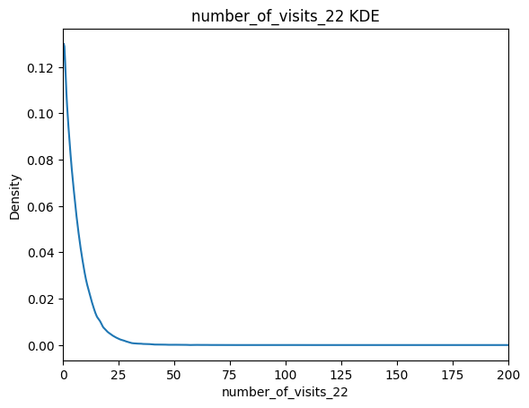

```python
train['number_of_visits_22'].plot.kde()
plt.title('number_of_visits_22 KDE')
plt.xlabel('number_of_visits_22')
plt.xlim((0,200));
```

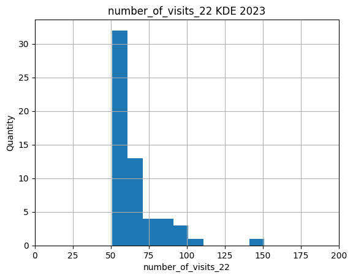

```python
train['number_of_visits_22'][train['number_of_visits_22'] > 50].hist()
plt.title('number_of_visits_22 KDE 2023')
plt.xlabel('number_of_visits_22')
plt.ylabel('Quantity')
plt.xlim((0,200));
```

```python
train[train['number_of_visits_22'] > 125]
```

| insured_pin | insured_network | nationality | gender | relation | dob | diagnoses | has_chronic_disease | exposition_22 | number_of_visits_22 | number_of_services_22 | exposition_23 | number_of_visits_23 |
| --- | --- | --- | --- | --- | --- | --- | --- | --- | --- | --- | --- | --- |
| 1419016 | Network-2 | Saudi | Male | Self | 1946-05-31 | R52.9;K29.1;E13.52;M54.5;E10.42;I87.2;I95.9;A4... | 1 | 365 | 151 | 962 | 365 | 202 |

**Corollary:** Great predictive value from correlation alone. There is an outlier, it is likely better to remove it to avoid confusion.

### 6.12. number_of_services_22

```python
train['number_of_services_22'].describe()
```

```
count    50000.000000
mean        22.477420
std         29.714146
min          0.000000
25%          3.000000
50%         13.000000
75%         31.000000
max        962.000000
Name: number_of_services_22, dtype: float64
```

```python
train['number_of_services_22'].value_counts().head(10)
```

```
0     8774
2     1720
4     1595
3     1540
5     1432
6     1375
7     1308
8     1299
9     1222
10    1116
Name: number_of_services_22, dtype: int64
```

```python
target_corr('number_of_services_22')
```

|  | corr with number_of_services_22 |
| --- | --- |
| number_of_visits_22 | 0.875023 |
| number_of_visits_23 | 0.613905 |

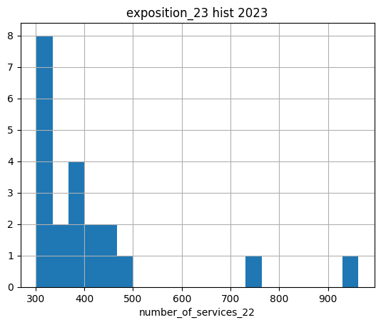

```python
train['number_of_services_22'][train['number_of_services_22'] > 300].hist(bins = 20)
plt.title('exposition_23 hist 2023')
plt.xlabel('number_of_services_22');
```

```python
train[train['number_of_services_22'] > 700]
```

| insured_pin | insured_network | nationality | gender | relation | dob | diagnoses | has_chronic_disease | exposition_22 | number_of_visits_22 | number_of_services_22 | exposition_23 | number_of_visits_23 |
| --- | --- | --- | --- | --- | --- | --- | --- | --- | --- | --- | --- | --- |
| 1419016 | Network-2 | Saudi | Male | Self | 1946-05-31 | R52.9;K29.1;E13.52;M54.5;E10.42;I87.2;I95.9;A4... | 1 | 365 | 151 | 962 | 365 | 202 |
| 1431423 | Network-2 | Saudi | Male | Self | 1978-04-24 | G62.9;E27.3;E11;E03;H16.0;M79.66;R06.0;M25.5;J... | 0 | 365 | 104 | 754 | 365 | 140 |

Two outliers, one from previous feature and a new one. See little reason not to remove them.

### 6.13. exposition_23

```python
train['exposition_23'].describe()
```

```
count    50000.000000
mean       355.588420
std         43.779065
min         50.000000
25%        365.000000
50%        365.000000
75%        365.000000
max        365.000000
Name: exposition_23, dtype: float64
```

```python
train['exposition_23'].value_counts().head(10)
```

```
365    47278
211      111
156      110
268       99
207       92
206       84
301       78
147       78
78        73
238       66
Name: exposition_23, dtype: int64
```

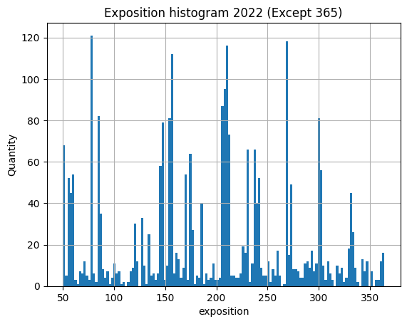

```python
train['exposition_23'][train['exposition_23'] < 365].hist(bins=140)
plt.title('Exposition histogram 2022 (Except 365)')
plt.xlabel('exposition')
plt.ylabel('Quantity');
```

```python
print('Correlation between exposure and visits in 2023')
train['exposition_23'].corr(train['number_of_visits_23'])
```

```
Correlation between exposure and visits in 2023
```

```
0.11764494226561621
```

```python
print('Correlation between exposure (<365) and visits in 2023')
train['exposition_23'][train['exposition_23'] < 365].corr(train['number_of_visits_23'])
```

```
Correlation between exposure (<365) and visits in 2023
```

```
0.14362665334899222
```

```python
train['number_of_visits_23'].groupby(train['exposition_23'] == 365).mean()
```

```
exposition_23
False    2.372888
True     6.101866
Name: number_of_visits_23, dtype: float64
```

### 6.14. number_of_visits_23

```python
train['number_of_visits_23'].describe()
```

```
count    50000.000000
mean         5.898860
std          6.856904
min          0.000000
25%          1.000000
50%          4.000000
75%          8.000000
max        202.000000
Name: number_of_visits_23, dtype: float64
```

```python
train['number_of_visits_23'].value_counts().head(10)
```

```
0    8525
1    5592
2    4931
3    4515
4    3773
5    3289
6    2847
7    2304
8    2063
9    1706
Name: number_of_visits_23, dtype: int64
```

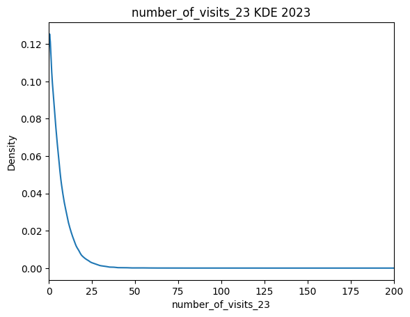

```python
train['number_of_visits_23'].plot.kde()
plt.title('number_of_visits_23 KDE 2023')
plt.xlabel('number_of_visits_23')
plt.xlim((0,200));
```

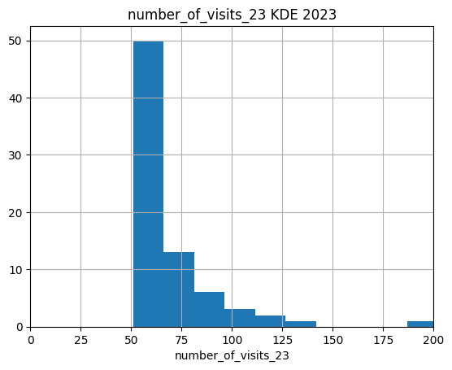

```python
train['number_of_visits_23'][train['number_of_visits_23'] > 50].hist()
plt.title('number_of_visits_23 KDE 2023')
plt.xlabel('number_of_visits_23')
plt.xlim((0,200));
```

```python
train[train['number_of_visits_23'] > 150]
```

| insured_pin | insured_network | nationality | gender | relation | dob | diagnoses | has_chronic_disease | exposition_22 | number_of_visits_22 | number_of_services_22 | exposition_23 | number_of_visits_23 |
| --- | --- | --- | --- | --- | --- | --- | --- | --- | --- | --- | --- | --- |
| 1419016 | Network-2 | Saudi | Male | Self | 1946-05-31 | R52.9;K29.1;E13.52;M54.5;E10.42;I87.2;I95.9;A4... | 1 | 365 | 151 | 962 | 365 | 202 |

**Corollary:** The target feature has the same outlier as `number_of_visits_22`, reinforcing the need to remove it. Otherwise no anomalies.

### 6.15. Conclusion

The data has good overall quality, missing 20% diagnoses are likely cause by technical error during data transfer of records without diagnoses. Some anomalies are best handled manually and left outside the model.

Features like `nationality`, `insured_network` are very poorly balanced, with overwhelming majority being `Saudi` persons with `Network-2` access, but it is not a complete overlap. But there does not appear to be a good reason to balance classes, it is not clear if they should be used at all.

`Gender` is well balanced, given context it might be useful to split the ML into several models, to handle man, women and children separately.

`Relation` does not present issues, and is useful in business sense, but it's hard to see how it will affect the model.

Age, chronic diseases and numeric features are all informative and useful, but `number_of_services_22` has an 87% correlation with `number_of_visits_22`, likely to cause multicollinearity issues.

Finally `diagnoses` presents the greatest challenge, as each patient has a unique set of diseases. Given that singling out diseases most likely to increase number of visits will be useful to the company, this is a good feature to keep.

## 7. Preprocessing

### 7.1. Missing values

#### 7.1.1. diagnoses

```python
train.diagnoses.fillna('no_diagnoses', inplace=True)
holdout.diagnoses.fillna('no_diagnoses', inplace=True)
```

#### 7.1.2. age

```python
train[train.dob.isnull()]
```

| insured_pin | insured_network | nationality | gender | relation | dob | diagnoses | has_chronic_disease | exposition_22 | number_of_visits_22 | number_of_services_22 | exposition_23 | number_of_visits_23 |
| --- | --- | --- | --- | --- | --- | --- | --- | --- | --- | --- | --- | --- |
| 1451433 | Network-2 | Saudi | Male | Self | NaT | H93.1;A09.9;R10;N39.0;M79;E78.5;N77.1;M23;E11.... | 1 | 365 | 15 | 62 | 365 | 14 |

```python
age = (2023 - train['dob'].dt.year).rename('age') # duplicated for convenience
age.describe()
```

```
count    49999.000000
mean        33.365907
std         22.741768
min          1.000000
25%         12.000000
50%         32.000000
75%         52.000000
max        103.000000
Name: age, dtype: float64
```

```python
age.isna().sum()
```

```
1
```

```python
dob_mean = pd.to_datetime(
    (2023 - pd.concat([train, age], axis=1) \
     .groupby(['nationality', 'gender', 'relation', 'has_chronic_disease']).mean()['age']),
    format='%Y').rename('dob_average')
dob_mean
```

```
nationality  gender  relation  has_chronic_disease
Group 1      Female  Spouse    0                     1985-01-01
                               1                     1982-01-01
             Male    Child     0                     2011-01-01
                     Self      0                     1982-01-01
                               1                     1978-01-01
                                                        ...
Saudi        Male    Parent    1                     1951-01-01
                     Self      0                     1972-01-01
                               1                     1976-01-01
                     Spouse    0                     1984-01-01
                               1                     1987-01-01
Name: dob_average, Length: 71, dtype: datetime64[ns]
```

```python
def dob_sample_mean(sample): # could do fillna instead, but inplace inside a function seems unsafe
    return sample.merge(dob_mean, how='left',
                        on=['nationality', 'gender', 'relation', 'has_chronic_disease']).set_index(sample.index)['dob_average']
```

```python
train.dob.fillna(dob_sample_mean(train), inplace=True)
holdout.dob.fillna(dob_sample_mean(train), inplace=True)
```

```python
train.isna().sum().sum()
```

```
0
```

```python
holdout.isna().sum().sum()
```

```
0
```

**Corollary:** `diagnoses` NA filled with dummy. `dob` NA filled with known (`train`) averages based on gender, nationality, chronic disease and relation.

### 7.2. Anomalies

```python
train[train['number_of_services_22'] > 700]
```

| insured_pin | insured_network | nationality | gender | relation | dob | diagnoses | has_chronic_disease | exposition_22 | number_of_visits_22 | number_of_services_22 | exposition_23 | number_of_visits_23 |
| --- | --- | --- | --- | --- | --- | --- | --- | --- | --- | --- | --- | --- |
| 1419016 | Network-2 | Saudi | Male | Self | 1946-05-31 | R52.9;K29.1;E13.52;M54.5;E10.42;I87.2;I95.9;A4... | 1 | 365 | 151 | 962 | 365 | 202 |
| 1431423 | Network-2 | Saudi | Male | Self | 1978-04-24 | G62.9;E27.3;E11;E03;H16.0;M79.66;R06.0;M25.5;J... | 0 | 365 | 104 | 754 | 365 | 140 |

```python
train.drop([1419016, 1431423], inplace=True)
```

**Corollary:** Removed outliers. See EDA for details

### 7.3. Test split

```python
feat = train.drop('number_of_visits_23', axis=1).copy()
targ = train['number_of_visits_23'].copy()
```

```python
feat_train, feat_test, targ_train, targ_test = train_test_split(feat, targ, test_size=10000, random_state=RANDOM)
```

```python
feat_holdout = holdout.copy()
```

**Corollary:** To avoid overfitting train sample is split into train and test. Once model is determined, they can be gathered back together to predict holdout

### 7.4. Feature construction

```python
sample_list = [feat_train, feat_test, feat_holdout]

for sample in sample_list:
    sample['age'] = 2023 - sample.dob.dt.year
    sample['has_chronic_disease'] = sample.has_chronic_disease.astype('bool')
    sample['diagnoses'] = sample['diagnoses'].fillna('no_diagnoses').str.lower().str.split(';')
    sample['diagnoses_counts'] = sample['diagnoses'].map(lambda x: 0 if x == ['no_diagnoses'] else len(x))
    sample['exposition_23_full'] = sample['exposition_23'] == 365
    sample[['insured_network', 'nationality', 'gender', 'relation']] =\
        sample[['insured_network', 'nationality', 'gender', 'relation']].astype('category')
```

**Corollary:** Date of birth replaced with `age`. Chronic diseases type changed to boolean. Added `exposition_23_full`, it might simplify decision making for some models. Restructured `diagnoses` to skip tokenization. Categorical features data type changed to `categorical`.

`insured_network` can be replaced with integer to denote quality of care, but there does not seem to be a straightforward relation between it and target, and as such I decided against it.

### 7.5. Conclusion

```python
feat_train
```

| insured_pin | insured_network | nationality | gender | relation | dob | diagnoses | has_chronic_disease | exposition_22 | number_of_visits_22 | number_of_services_22 | exposition_23 | age | diagnoses_counts | exposition_23_full |
| --- | --- | --- | --- | --- | --- | --- | --- | --- | --- | --- | --- | --- | --- | --- |
| 1489111 | Network-2 | Saudi | Female | Self | 1946-05-31 | [no_diagnoses] | False | 365 | 0 | 0 | 365 | 77 | 0 | True |
| 1504934 | Network-2 | Saudi | Male | Self | 1959-12-30 | [no_diagnoses] | False | 365 | 0 | 0 | 78 | 64 | 0 | False |
| 1531337 | Network-2 | Saudi | Male | Child | 2006-11-23 | [no_diagnoses] | False | 365 | 0 | 0 | 365 | 17 | 0 | True |
| 1408159 | Network-2 | Saudi | Male | Self | 1994-08-27 | [j06.9, r10.4, h60, r31, n23] | True | 365 | 4 | 30 | 365 | 29 | 5 | True |
| 1522775 | Network-2 | Saudi | Male | Self | 1957-01-31 | [h81.1, z01.9, z96.1, j02.9, h40.9, e11, i25, ... | True | 365 | 17 | 130 | 365 | 66 | 21 | True |
| ... | ... | ... | ... | ... | ... | ... | ... | ... | ... | ... | ... | ... | ... | ... |
| 2435833 | Network-2 | Saudi | Male | Child | 2019-07-23 | [t16, j00, j03] | True | 365 | 3 | 6 | 365 | 4 | 3 | True |
| 2437475 | Network-2 | Saudi | Female | Spouse | 1995-12-21 | [r07.4, d64, n93, n97, n93.9, e28, j02, j34, r... | True | 365 | 14 | 38 | 365 | 28 | 10 | True |
| 3147918 | Network-2 | Saudi | Female | Child | 2020-11-26 | [z27.9, j20, k90.4, t78.4, r69, k59.0, j02.9, ... | True | 365 | 8 | 33 | 365 | 3 | 14 | True |
| 1414692 | Network-2 | Saudi | Female | Self | 1960-12-19 | [h01.0, r14, r10.1, l20, d50, e13.9, k29.70, m... | False | 365 | 10 | 45 | 365 | 63 | 23 | True |
| 1382608 | Network-2 | Saudi | Male | Self | 1991-08-23 | [z10.1, z10.8] | False | 365 | 1 | 1 | 365 | 32 | 2 | True |

39998 rows × 14 columns

General preprocessing complete, anomalies handled, missing values reconciled. Data is split into features and target, test is split off as a safeguard against overfitting. Feature selection and transformations are handled in the next section.

## 8. Feature Engineering

### 8.1. Preface

```python
feat_train_backup = feat_train.copy()
feat_test_backup = feat_test.copy()
feat_holdout_backup = feat_holdout.copy()
```

Backups above allow to restart feature engineering process w/o restarting notebook

From here on a lot of decisions are made on experimental basis, for brevity's sake experiments are not fully demonstrated, I'll describe part of the process and conclusions I came to here.

To test various configurations I was using baseline LGBM, XGB and LinearRegression models, using `cross_val_mean`and `eval_baseline` functions defined in Machine learning section to catalogue time and results.

1. Number of features, namely `exposition_22, diagnoses_counts, number_of_services_22, insured_network, nationality, gender, relation` have a fairly low impact on model, being overshadowed by others. Kept them on first iteration because it's unclear if there's a downside to it and they do provide a small benefit. It is possible this will result in overfitting, but that can be verified on `test`. Performance impact on the other had is heavily influenced by use circumstances.
2. For `diagnoses` I tried CountVectorizer(), TfidfVectorizer(), not using it at all, and extending it by including pairs of diagnoses (not just N-Grams, all pairs). Contrary to my expectations simple `CountVectorizer` has shown best results, tho margin is minor.
3. Scaler proved unnecessary - linear_reg is not the best model so it's not used for interpretation, and the others handle it well enough without. Maintained in a disabled state as part of the code for backup and ease of access to feature list of overall column transfer input.

### 8.2. Feature Selection

feat_train = feat_train_backup.copy() feat_test = feat_test_backup.copy() feat_holdout = feat_holdout_backup.copy() selected_features = ['insured_network', 'nationality', 'gender', 'relation', #'dob', 'diagnoses', 'has_chronic_disease', 'exposition_22', 'number_of_visits_22', 'number_of_services_22', 'exposition_23', 'age', 'diagnoses_counts', #'exposition_23_full' ] feat_train = feat_train[selected_features] feat_test = feat_test[selected_features] feat_holdout = feat_holdout[selected_features]

**Corollary:** `exposition_23_full` proved useless, removing `exposition_22, diagnoses_counts, number_of_services_22, insured_network, nationality, gender, relation`, has very minor negative effects on MSE, but it is negative.

### 8.3. Overview

```python
feat_train.info()
```

```
<class 'pandas.core.frame.DataFrame'>
Int64Index: 39998 entries, 1489111 to 1382608
Data columns (total 14 columns):
 #   Column                 Non-Null Count  Dtype
---  ------                 --------------  -----
 0   insured_network        39998 non-null  category
 1   nationality            39998 non-null  category
 2   gender                 39998 non-null  category
 3   relation               39998 non-null  category
 4   dob                    39998 non-null  datetime64[ns]
 5   diagnoses              39998 non-null  object
 6   has_chronic_disease    39998 non-null  bool
 7   exposition_22          39998 non-null  int64
 8   number_of_visits_22    39998 non-null  int64
 9   number_of_services_22  39998 non-null  int64
 10  exposition_23          39998 non-null  int64
 11  age                    39998 non-null  int64
 12  diagnoses_counts       39998 non-null  int64
 13  exposition_23_full     39998 non-null  bool
dtypes: bool(2), category(4), datetime64[ns](1), int64(6), object(1)
memory usage: 3.0+ MB
```

```python
feat_train
```

| insured_pin | insured_network | nationality | gender | relation | dob | diagnoses | has_chronic_disease | exposition_22 | number_of_visits_22 | number_of_services_22 | exposition_23 | age | diagnoses_counts | exposition_23_full |
| --- | --- | --- | --- | --- | --- | --- | --- | --- | --- | --- | --- | --- | --- | --- |
| 1489111 | Network-2 | Saudi | Female | Self | 1946-05-31 | [no_diagnoses] | False | 365 | 0 | 0 | 365 | 77 | 0 | True |
| 1504934 | Network-2 | Saudi | Male | Self | 1959-12-30 | [no_diagnoses] | False | 365 | 0 | 0 | 78 | 64 | 0 | False |
| 1531337 | Network-2 | Saudi | Male | Child | 2006-11-23 | [no_diagnoses] | False | 365 | 0 | 0 | 365 | 17 | 0 | True |
| 1408159 | Network-2 | Saudi | Male | Self | 1994-08-27 | [j06.9, r10.4, h60, r31, n23] | True | 365 | 4 | 30 | 365 | 29 | 5 | True |
| 1522775 | Network-2 | Saudi | Male | Self | 1957-01-31 | [h81.1, z01.9, z96.1, j02.9, h40.9, e11, i25, ... | True | 365 | 17 | 130 | 365 | 66 | 21 | True |
| ... | ... | ... | ... | ... | ... | ... | ... | ... | ... | ... | ... | ... | ... | ... |
| 2435833 | Network-2 | Saudi | Male | Child | 2019-07-23 | [t16, j00, j03] | True | 365 | 3 | 6 | 365 | 4 | 3 | True |
| 2437475 | Network-2 | Saudi | Female | Spouse | 1995-12-21 | [r07.4, d64, n93, n97, n93.9, e28, j02, j34, r... | True | 365 | 14 | 38 | 365 | 28 | 10 | True |
| 3147918 | Network-2 | Saudi | Female | Child | 2020-11-26 | [z27.9, j20, k90.4, t78.4, r69, k59.0, j02.9, ... | True | 365 | 8 | 33 | 365 | 3 | 14 | True |
| 1414692 | Network-2 | Saudi | Female | Self | 1960-12-19 | [h01.0, r14, r10.1, l20, d50, e13.9, k29.70, m... | False | 365 | 10 | 45 | 365 | 63 | 23 | True |
| 1382608 | Network-2 | Saudi | Male | Self | 1991-08-23 | [z10.1, z10.8] | False | 365 | 1 | 1 | 365 | 32 | 2 | True |

39998 rows × 14 columns

**Corollary:** There are four groups of features remaining - categoricals, booleans, integers and object - diagnoses.

Each will require a somewhat different approach and transformer. First transformers will be fine tuned separately, then united with `ColumnTransformers` to fit the whole `feat_train` and transform samples.

### 8.4. Int - StandardScaler

```python
int_features = feat_train.select_dtypes('int64').columns
int_features
```

```
Index(['exposition_22', 'number_of_visits_22', 'number_of_services_22',
       'exposition_23', 'age', 'diagnoses_counts'],
      dtype='object')
```

```python
# testing and display purposes only
s_scaler = StandardScaler(with_mean=False, with_std=False)
s_scaler.fit(feat_train[int_features])
s_scaler.transform(feat_train[int_features])
```

```
array([[365.,   0.,   0., 365.,  77.,   0.],
       [365.,   0.,   0.,  78.,  64.,   0.],
       [365.,   0.,   0., 365.,  17.,   0.],
       ...,
       [365.,   8.,  33., 365.,   3.,  14.],
       [365.,  10.,  45., 365.,  63.,  23.],
       [365.,   1.,   1., 365.,  32.,   2.]])
```

**Corollary:** With mean and std disable this is a dummy.

### 8.5. Categoricals - OHE

```python
MIN_FREQ = .015

#MAX_CATEG = 3

# display(feat_train.insured_network.value_counts(normalize=True))
# Network-1    0.028476
# Network-4    0.019326
# Network-5    0.011426

# display(feat_train.relation.value_counts(normalize=True))
# Child     0.392270
# Spouse    0.168958

# display(feat_train.nationality.value_counts(normalize=True))
# Group 2    0.027826
# Group 3    0.022176
```

```python
categorical_features = feat_train.select_dtypes('category').columns
categorical_features
```

```
Index(['insured_network', 'nationality', 'gender', 'relation'], dtype='object')
```

```python
freq_cat_dict = dict(zip(
    feat_train.select_dtypes('category').columns,
    [feat_train[x].value_counts().head(1).index[0] for x in feat_test.select_dtypes('category').columns] # most frequent
))
freq_cat_dict
```

```
{'insured_network': 'Network-2',
 'nationality': 'Saudi',
 'gender': 'Male',
 'relation': 'Self'}
```

```python
freq_categories = [freq_cat_dict[x] for x in categorical_features]
freq_categories
```

```
['Network-2', 'Saudi', 'Male', 'Self']
```

```python
# testing and display purposes only
ohe = OneHotEncoder(
    handle_unknown='infrequent_if_exist',
    drop=freq_categories,
    min_frequency=MIN_FREQ
)
ohe.fit(feat_train[categorical_features])
ohe.transform(feat_train[categorical_features])
```

```
<39998x10 sparse matrix of type '<class 'numpy.float64'>'
	with 47383 stored elements in Compressed Sparse Row format>
```

```python
ohe.categories_
```

```
[array(['Network-1', 'Network-2', 'Network-3', 'Network-4', 'Network-5',
        'Network-6', 'Network-7', 'Network-8'], dtype=object),
 array(['Group 1', 'Group 2', 'Group 3', 'Group 4', 'Others', 'Saudi'],
       dtype=object),
 array(['Female', 'Male'], dtype=object),
 array(['Child', 'Other', 'Parent', 'Self', 'Spouse'], dtype=object)]
```

```python
ohe.infrequent_categories_
```

```
[array(['Network-3', 'Network-5', 'Network-6', 'Network-7', 'Network-8'],
       dtype=object),
 array(['Group 1', 'Group 4', 'Others'], dtype=object),
 None,
 array(['Other', 'Parent'], dtype=object)]
```

**Corollary:** Used OHE to encode categories. Dropped the most frequent, leaving it as "default". Set `min_frequency` to group together rare categories. The numbers are still small, but should at least be less prone to overfitting.

### 8.6. Diagnoses - CountVectorizer

```python
def dummy_analyzer(tokens:list):
    return tokens
```

```python
tf_idf = CountVectorizer(
    binary=True,
    analyzer=dummy_analyzer
)

tf_idf.fit(feat_train.diagnoses)
tf_idf.transform(feat_train.diagnoses)
```

```
<39998x5810 sparse matrix of type '<class 'numpy.int64'>'
	with 233645 stored elements in Compressed Sparse Row format>
```

**Corollary:** Despite the dimensions the sparse nature of the matrix allows for fairly quickly processing. dummy_analyzer is used to skip tokenization, as data is already in list format. CountVectorizer set to binary shows slightly better results than TF-IDF, likely because TF-IDF too stays static given that each diagnosis is unique for each patient.

### 8.7. DataFrame - ColumnTransformer

```python
column_trans = ColumnTransformer(
    [('categories', ohe, categorical_features),
     ('diagnoses', tf_idf, 'diagnoses'),
     ('ints', s_scaler, int_features),
     ('bools', OneHotEncoder(drop='first'), feat_train.select_dtypes('bool').columns) # to sparse the bool or not to sparse the bool
    ],
    verbose_feature_names_out = False,
)

column_trans.fit(feat_train)
```

```
ColumnTransformer(transformers=[('categories',
                                 OneHotEncoder(drop=['Network-2', 'Saudi',
                                                     'Male', 'Self'],
                                               handle_unknown='infrequent_if_exist',
                                               min_frequency=0.015),
                                 Index(['insured_network', 'nationality', 'gender', 'relation'], dtype='object')),
                                ('diagnoses',
                                 CountVectorizer(analyzer=<function dummy_analyzer at 0x0000025908EA6040>,
                                                 binary=True),
                                 'diagnoses'),
                                ('ints',
                                 StandardScaler(with_mean=False,
                                                with_std=False),
                                 Index(['exposition_22', 'number_of_visits_22', 'number_of_services_22',
       'exposition_23', 'age', 'diagnoses_counts'],
      dtype='object')),
                                ('bools', OneHotEncoder(drop='first'),
                                 Index(['has_chronic_disease', 'exposition_23_full'], dtype='object'))],
                  verbose_feature_names_out=False)
```

```python
feat_train_trans = column_trans.transform(feat_train)
feat_test_trans = column_trans.transform(feat_test)
```

**Corollary:** `ColumnTransformer` enables use of all of the above transformers together. Data is ready for ML.

### 8.8. Conclusion

def dummy_analyzer(tokens:list): return tokens feat_train = feat_train_backup.copy() feat_test = feat_test_backup.copy() feat_holdout = feat_holdout_backup.copy() MAX_DF = 1.0 MIN_FREQ = 0.15 selected_features = ['insured_network', 'nationality', 'gender', 'relation', #'dob', 'diagnoses', 'has_chronic_disease', 'exposition_22', 'number_of_visits_22', 'number_of_services_22', 'exposition_23', 'age', 'diagnoses_counts', #'exposition_23_full' ] feat_train = feat_train[selected_features] feat_test = feat_test[selected_features] feat_holdout = feat_holdout[selected_features] int_features = feat_train.select_dtypes('int64').columns categorical_features = feat_train.select_dtypes('category').columns freq_cat_dict = dict(zip( feat_train.select_dtypes('category').columns, [feat_train[x].value_counts().head(1).index[0] for x in feat_test.select_dtypes('category').columns] # most frequent )) freq_categories = [freq_cat_dict[x] for x in categorical_features] freq_categories column_trans = ColumnTransformer( [('categories', OneHotEncoder( handle_unknown='infrequent_if_exist', min_frequency=MIN_FREQ, drop=freq_categories ), categorical_features), # ('diagnoses', TfidfVectorizer(max_df=MAX_DF, analyzer=dummy_analyzer), 'diagnoses'), ('diagnoses', CountVectorizer(binary=True, analyzer=dummy_analyzer), 'diagnoses'), # ('ints', StandardScaler(), int_features), ('ints', StandardScaler(with_mean=False, with_std=False), int_features), ('bools', OneHotEncoder(), feat_train.select_dtypes('bool').columns) # to sparse the bool or not to sparse the bool ], verbose_feature_names_out = False, # remainder='passthrough' # remainder= OneHotEncoder() ) column_trans.fit(feat_train) feat_train_trans = column_trans.transform(feat_train) feat_test_trans = column_trans.transform(feat_test) feat_holdout_trans = column_trans.transform(feat_holdout) column_trans

**Corollary:** Feature engineering is complete. Cell above is disabled, but allows to perform entire section post preface all at once if needed and has additional options for transformers.

## 9. Machine Learning

### 9.1. Defines

```python
def cross_val_mean(model):
    return (-cross_val_score(model, feat_train_trans, targ_train, scoring='neg_mean_squared_error', cv=4, n_jobs=3)).mean()

def eval_baseline(model_list):
    display(column_trans.get_params()['transformers'])
    results = pd.DataFrame()
    start_time = default_timer()
    for model in model_list:
        results.loc[type(model).__name__, ['CrossVal mean', 'Process time']] = [
            cross_val_mean(model),
            default_timer() - start_time
        ]
        start_time = default_timer()
    return(results)
```

```python
lin_reg = LinearRegression()
#ran_fst = RandomForestRegressor(random_state=RANDOM)
lgbm = LGBMRegressor(random_state=RANDOM, verbose=0)
xgb = XGBRegressor(random_state=RANDOM, verbose=1)
cat_b = CatBoostRegressor(random_state=RANDOM, verbose=1)
```

```python
#model_list_short = [lin_reg, lgbm, xgb]
model_list = [lin_reg, lgbm, xgb, cat_b] #, ran_fst - too slow
```

```python
eval_baseline(model_list)
```

```
[('categories',
  OneHotEncoder(drop=['Network-2', 'Saudi', 'Male', 'Self'],
                handle_unknown='infrequent_if_exist', min_frequency=0.015),
  Index(['insured_network', 'nationality', 'gender', 'relation'], dtype='object')),
 ('diagnoses',
  CountVectorizer(analyzer=<function dummy_analyzer at 0x0000025908EA6040>,
                  binary=True),
  'diagnoses'),
 ('ints',
  StandardScaler(with_mean=False, with_std=False),
  Index(['exposition_22', 'number_of_visits_22', 'number_of_services_22',
         'exposition_23', 'age', 'diagnoses_counts'],
        dtype='object')),
 ('bools',
  OneHotEncoder(drop='first'),
  Index(['has_chronic_disease', 'exposition_23_full'], dtype='object'))]
```

|  | CrossVal mean | Process time |
| --- | --- | --- |
| LinearRegression | 34.862787 | 4.686953 |
| LGBMRegressor | 23.278600 | 1.795972 |
| XGBRegressor | 23.921054 | 2.313624 |
| CatBoostRegressor | 23.518477 | 100.569768 |

**Corollary:** Defined functions and variables allow for relatively quick estimation of basic models.

### 9.2. Search CV

```python
def scv_results(clf):

    e_score = -clf.best_score_
    e_index = type(clf.best_estimator_).__name__
    return pd.DataFrame(e_score, columns=['SearchCV'], index=[e_index])
```

### 9.3. LGBM

```python
feature_name=column_trans.get_feature_names_out()
```

```python
%%time

parameters = {
    'boosting_type' : ['gbdt', 'dart'],
    'num_leaves': [50, 100, 200],
    'max_depth': [4, 6, 8],
    'n_estimators' : [100, 150, 200],
    'learning_rate' : [0.1, .01, .001]
    }
clf_lgbm = RandomizedSearchCV(LGBMRegressor(random_state=RANDOM), parameters, verbose=2,
                              scoring='neg_mean_squared_error', n_jobs=4, cv=4, random_state=RANDOM, n_iter=30) #classifier
clf_lgbm.fit(feat_train_trans, targ_train, feature_name=list(column_trans.get_feature_names_out()))
scv_results(clf_lgbm)
```

[output not shown]

[output cut: 87 more lines]

[output not shown]

|  | SearchCV |
| --- | --- |
| LGBMRegressor | 22.98498 |

```python
scv_results(clf_lgbm)
```

|  | SearchCV |
| --- | --- |
| LGBMRegressor | 22.98498 |

**Corollary:** Slight improvement in quality.

### 9.4. XGB

```python
%%time

parameters = {
    'subsample': [0.5, .75, 1.],
    'max_depth': [4, 6, 8],
    'n_estimators' : [100, 150, 200],
    'eta' : [0.1, .01, .001]
    }
clf_xgb = RandomizedSearchCV(XGBRegressor(random_state=RANDOM), parameters, verbose=2, scoring='neg_mean_squared_error',
                             n_jobs=4, cv=4, random_state=RANDOM, n_iter=30) #classifier
clf_xgb.fit(feat_train_trans, targ_train)
scv_results(clf_xgb)
```

```
Fitting 4 folds for each of 30 candidates, totalling 120 fits
CPU times: total: 2.5 s
Wall time: 3min 37s
```

|  | SearchCV |
| --- | --- |
| XGBRegressor | 23.259304 |

**Corollary:** Better improvement than LGBM, but still behind.

### 9.5. Best model

```python
clf_lgbm.best_estimator_.get_params()
```

```
{'boosting_type': 'gbdt',
 'class_weight': None,
 'colsample_bytree': 1.0,
 'importance_type': 'split',
 'learning_rate': 0.1,
 'max_depth': 4,
 'min_child_samples': 20,
 'min_child_weight': 0.001,
 'min_split_gain': 0.0,
 'n_estimators': 150,
 'n_jobs': None,
 'num_leaves': 50,
 'objective': None,
 'random_state': 20240804,
 'reg_alpha': 0.0,
 'reg_lambda': 0.0,
 'subsample': 1.0,
 'subsample_for_bin': 200000,
 'subsample_freq': 0}
```

```python
pd.DataFrame(clf_lgbm.cv_results_).loc[clf_lgbm.best_index_]
```

```
mean_fit_time                                                   0.994995
std_fit_time                                                     0.06944
mean_score_time                                                 0.018993
std_score_time                                                  0.001223
param_num_leaves                                                      50
param_n_estimators                                                   150
param_max_depth                                                        4
param_learning_rate                                                  0.1
param_boosting_type                                                 gbdt
params                 {'num_leaves': 50, 'n_estimators': 150, 'max_d...
split0_test_score                                             -22.226588
split1_test_score                                             -22.659888
split2_test_score                                             -24.045251
split3_test_score                                             -23.008193
mean_test_score                                                -22.98498
std_test_score                                                  0.671855
rank_test_score                                                        1
Name: 11, dtype: object
```

**Corollary:** Decently low deviation is good to see, but might signal overfitting.

### 9.6. Test

```python
mean_squared_error(targ_test, clf_lgbm.predict(feat_test_trans))
```

```
23.3268842838393
```

**Corollary:** Result on test is slightly worse, but, importantly, does not show overfitting.

### 9.7. Feature importances

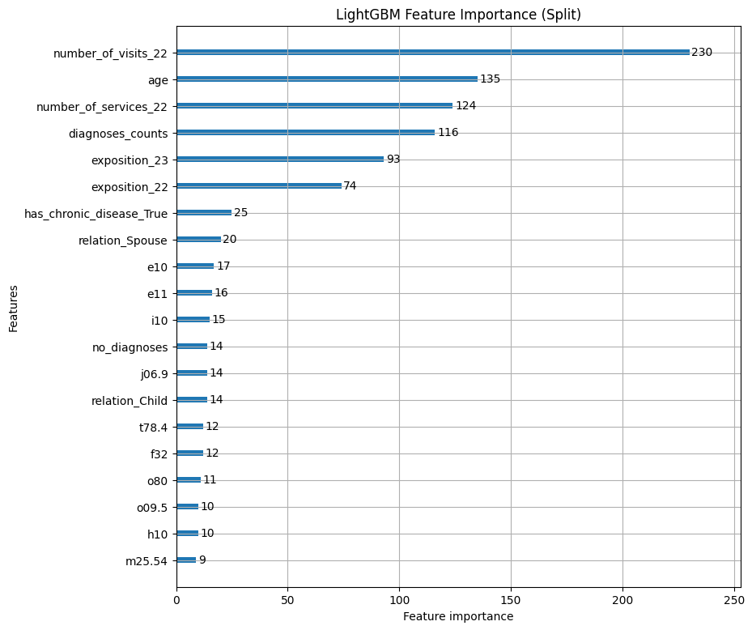

```python
plot_importance(clf_lgbm.best_estimator_, importance_type="split",
                    figsize=(9,9), title="LightGBM Feature Importance (Split)", max_num_features=20)
plt.show()
```

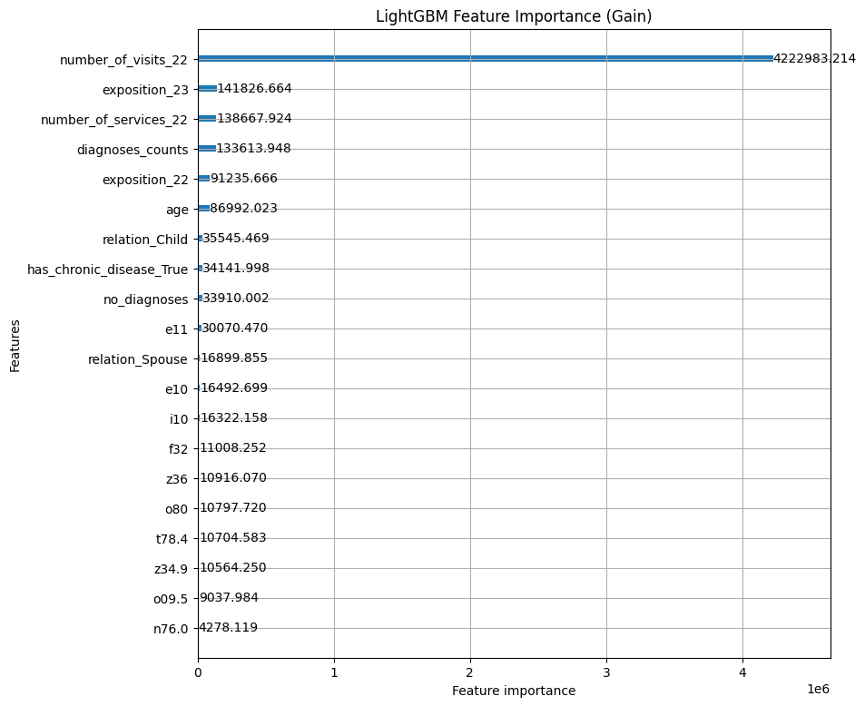

```python
plot_importance(clf_lgbm.best_estimator_, importance_type="gain",
                    figsize=(9,9), title="LightGBM Feature Importance (Gain)", max_num_features=20)
plt.show()
```

```python
feature_importances = pd.Series(clf_lgbm.best_estimator_.feature_importances_, index=column_trans.get_feature_names_out())
```

```python
feature_importances.sort_values(ascending=False).head(30)
```

```
number_of_visits_22         230
age                         135
number_of_services_22       124
diagnoses_counts            116
exposition_23                93
exposition_22                74
has_chronic_disease_True     25
relation_Spouse              20
e10                          17
e11                          16
i10                          15
relation_Child               14
j06.9                        14
no_diagnoses                 14
f32                          12
t78.4                        12
o80                          11
h10                          10
o09.5                        10
gender_Female                 9
m25.54                        9
g40                           8
o09.3                         8
r10                           7
h18.6                         7
n76.0                         7
z36                           7
z34.9                         7
z38.0                         7
m60                           7
dtype: int32
```

### 9.8. Conclusion

The most important feature, unsurprisingly, is number_of_visits_22, I suspect, should number_of_services_22 be removed, it wil absorb most of that number as well. It is interesting that despite number of splits being higher for number_of_services_22, diagnoses_counts and age accuracy gains are superior for exposition_23.

Relation apparently plays some role in decision making, but not nationality or network. Somewhat understandable given how imbalanced those categories are.

A good number of splits are made on the basis of disease tokens, this might be useful to determine the riskiest diseases.

## 10. Holdout

```python
feat_full = pd.concat([feat_train, feat_test])
feat_full_trans = column_trans.fit_transform(feat_full)
feat_full_trans
```

```
<49998x6240 sparse matrix of type '<class 'numpy.float64'>'
	with 689195 stored elements in Compressed Sparse Row format>
```

```python
targ_full = pd.concat([targ_train, targ_test])
targ_full
```

```
insured_pin
1489111     0
1504934     0
1531337     0
1408159     8
1522775    23
           ..
1440353     1
1545110     5
1464088     9
1347640     3
1370823    13
Name: number_of_visits_23, Length: 49998, dtype: int64
```

```python
feat_holdout_trans = column_trans.transform(feat_holdout)
feat_holdout_trans
```

```
<10000x6240 sparse matrix of type '<class 'numpy.float64'>'
	with 137971 stored elements in Compressed Sparse Row format>
```

```python
holdout_params = clf_lgbm.best_estimator_.get_params()
holdout_params.pop("random_state")
holdout_params
```

```
{'boosting_type': 'gbdt',
 'class_weight': None,
 'colsample_bytree': 1.0,
 'importance_type': 'split',
 'learning_rate': 0.1,
 'max_depth': 4,
 'min_child_samples': 20,
 'min_child_weight': 0.001,
 'min_split_gain': 0.0,
 'n_estimators': 150,
 'n_jobs': None,
 'num_leaves': 50,
 'objective': None,
 'reg_alpha': 0.0,
 'reg_lambda': 0.0,
 'subsample': 1.0,
 'subsample_for_bin': 200000,
 'subsample_freq': 0}
```

```python
holdout_model = LGBMRegressor(verbose=2, random_state=RANDOM, **holdout_params)
```

```python
holdout_model.fit(feat_full_trans, targ_full)
```

[output not shown]

[output cut: 232 more lines]

[output not shown]

```
LGBMRegressor(max_depth=4, n_estimators=150, num_leaves=50,
              random_state=20240804, verbose=2)
```

```python
train.columns
```

```
Index(['insured_network', 'nationality', 'gender', 'relation', 'dob',
       'diagnoses', 'has_chronic_disease', 'exposition_22',
       'number_of_visits_22', 'number_of_services_22', 'exposition_23',
       'number_of_visits_23'],
      dtype='object')
```

```python
holdout_pred = pd.Series(holdout_model.predict(feat_holdout_trans), index=(feat_holdout.index), name='number_of_visits_23')
holdout_pred.to_csv('holdout_pred.csv')
holdout_pred
```

```
Insured_PIN
1516424      2.157946
22210474     4.532833
1518945      6.080328
1344077      7.479994
1354276      4.793158
              ...
3948786     10.221633
67038285    10.130148
1371592      3.249993
62818434     2.441623
1384402     24.899270
Name: number_of_visits_23, Length: 10000, dtype: float64
```

```python
pd.read_csv('holdout_pred.csv')
```

|  | Insured_PIN | number_of_visits_23 |
| --- | --- | --- |
| 0 | 1516424 | 2.157946 |
| 1 | 22210474 | 4.532833 |
| 2 | 1518945 | 6.080328 |
| 3 | 1344077 | 7.479994 |
| 4 | 1354276 | 4.793158 |
| ... | ... | ... |
| 9995 | 3948786 | 10.221633 |
| 9996 | 67038285 | 10.130148 |
| 9997 | 1371592 | 3.249993 |
| 9998 | 62818434 | 2.441623 |
| 9999 | 1384402 | 24.899270 |

10000 rows × 2 columns

**Conclusion:** Data is regathered, transformed anew and on model is retrained on it. `holdout` predictions are saved to file.

*Thank you for reading the project.*

```python
feature_importances.sort_values(ascending=False).to_csv('feature_importances.csv')
```